# Project 2

Sonia Jahangiri

3/16/2022

This document provides an example of forecasting using Winter’s Method. The data used consists of RIT’s energy demand data.

# Task 1

In this part, the flowchart for making decision on Exponential smoothing method is provided.

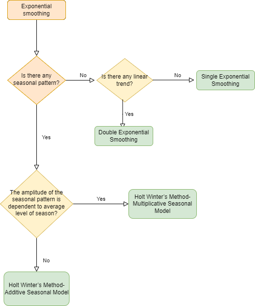

Figure 1: Exponential smoothing method decision flowchart

Based on this flowchart, the Holt Winter’s Method-Additive is good for the demand data of RIT because we have seasonal pattern in this data and also the amplitude of this pattern is independent from average level of season.

# Reading the data and aggregating it

First of all, I read the data set and changed the format of date, then I hourly aggregated the data

Here I provide the graph of whole data set after imputing missing values

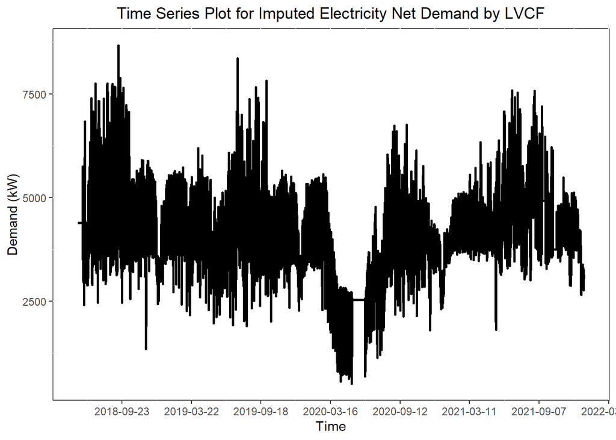

Figure 2: Graph of Original Data

# Splitting data and Providing difficult and easy test week

I have considered the Christmas week of 2019 as a difficult week and I have used the data from 2019 as training set.

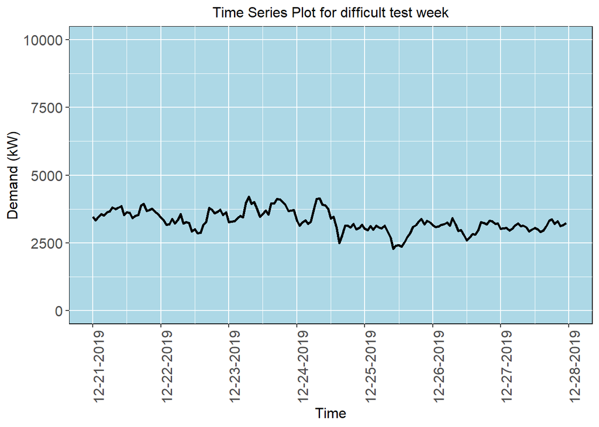

Figure 3: Graph of Difficult test set

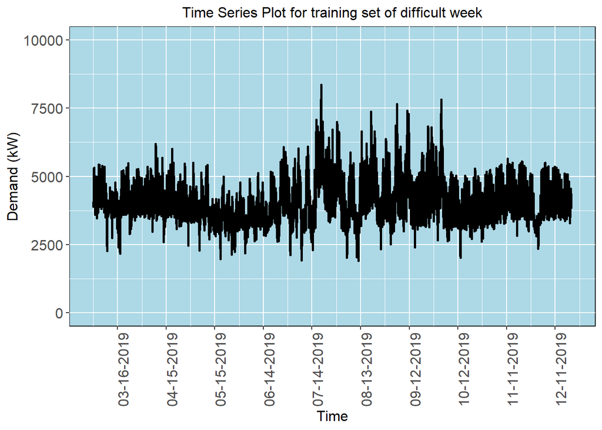

Figure 4: Graph of Difficult tarin set

I have considered a normal week in the spring semester of 2019 as a easy week, then I have used the data from 2018 and 2019 to train model.

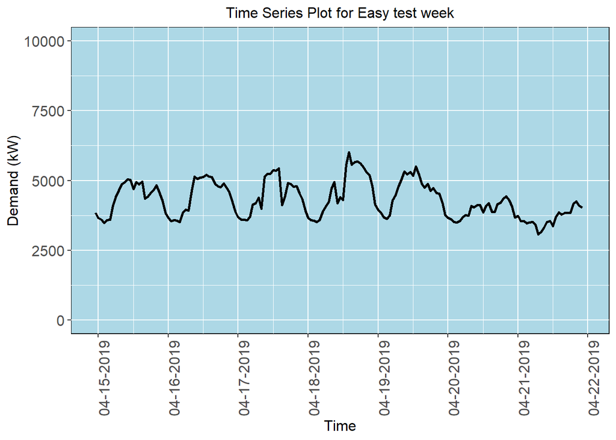

Figure 5: Graph of Easy test set

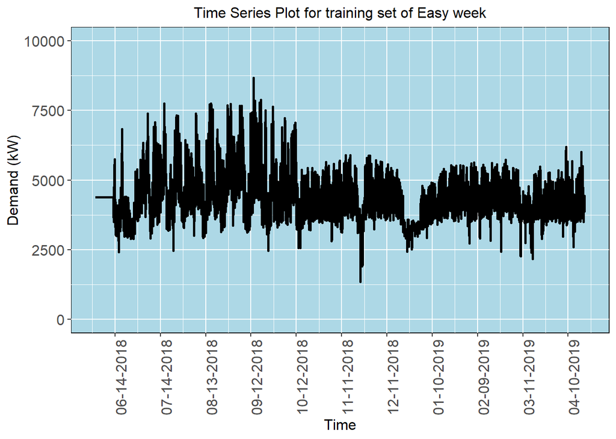

Figure 6: Graph of Easy tarin set

# Defining test and train set for difficult and easy weeks

The training and test set for difficult and easy week are provided.

```r
DifficultTrainSet <- imputedLVCF[DifficultTrainStart<=imputedLVCF$Time & imputedLVCF$Time<= DifficultTrainEnd,]
DifficultTestSet <- imputedLVCF[DifficultTestStart<=imputedLVCF$Time & imputedLVCF$Time<=DifficultTestEnd,]

EasyTrainSet <- imputedLVCF[EasyTrainstart<=imputedLVCF$Time & imputedLVCF$Time<= EasyTrainEnd,]
EasyTestSet <- imputedLVCF[EasyTestStart<=imputedLVCF$Time & imputedLVCF$Time<= EasyTestEnd,]

DifficultTrainingTS <- ts(DifficultTrainSet$net_demand,freq=168)
EasyTrainTS <- ts(EasyTrainSet$net_demand,freq=168)
```

# Training Holt Winter’s Method

In this section, I have used Holt Winter additive method to tain the difficult data set and easy data set. I did not quantify parameters of this model and just allowed R programming language to use the best parameters. The plots for original training data and smoothed data are provided here.

```r
hwDifficult<-HoltWinters(DifficultTrainingTS,seasonal="additive")
hwEasy<-HoltWinters(EasyTrainTS,seasonal="additive")
```

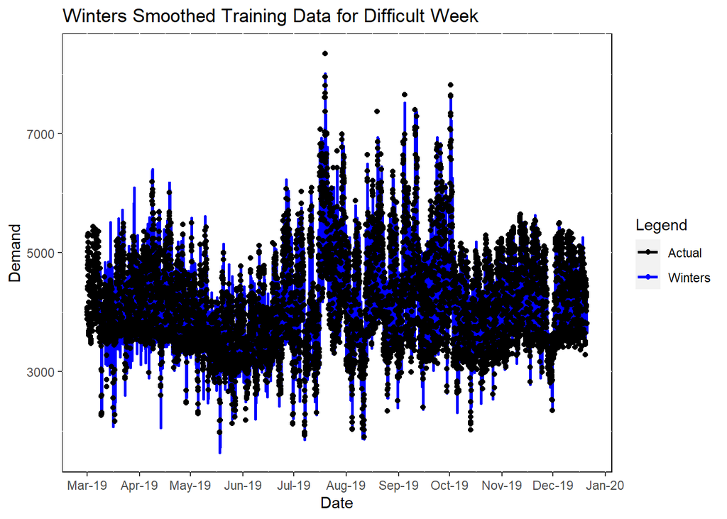

Figure 7: Exponentially smoothed data using Winters Method

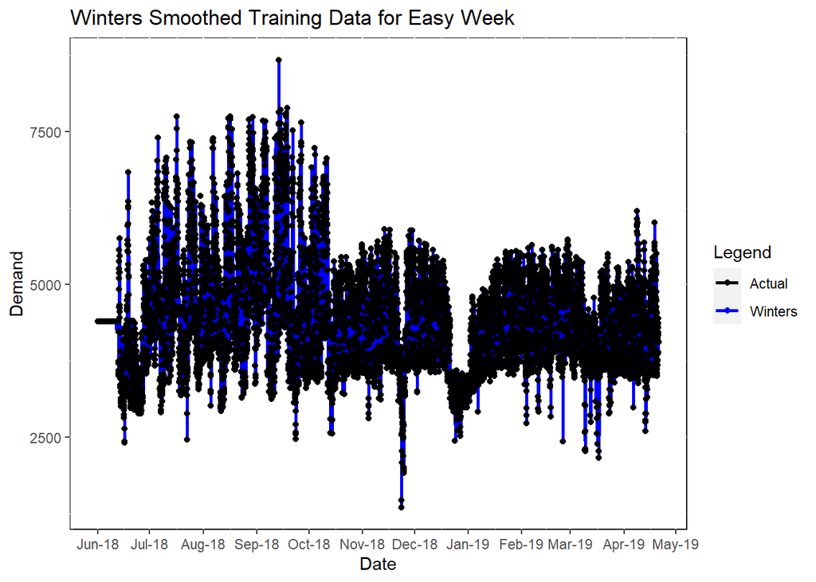

Figure 8: Exponentially smoothed data using Winters Method

In this section, the performance of the model based on different values of alpha, beta, gamma on the difficult week is investigated, for this purpose an empty data frame is created to keep track of our training data results. Based on the results from SSE, MSE, RMSE, we could conclude that the parameters which is selected by R has minimum error.

| Alpha | Beta | Gamma | SSE | MSE | RMSE | MAE test | MAPE test |
| --- | --- | --- | --- | --- | --- | --- | --- |
| 0.8154544 | 0.0 | 0.6861009 | 677461735 | 338730868 | 18404.64 | 1068.3847 | 34.07011 |
| 0.1000000 | 0.1 | 0.1000000 | 1826533505 | 913266753 | 30220.30 | NA | NA |
| 0.1000000 | 0.0 | 0.1000000 | 1255138253 | 627569127 | 25051.33 | NA | NA |
| 0.2000000 | 0.0 | 0.2000000 | 955597963 | 477798982 | 21858.61 | NA | NA |
| 0.2000000 | 0.1 | 0.2000000 | 1333696468 | 666848234 | 25823.40 | NA | NA |
| 0.6000000 | 0.1 | 0.5000000 | 1025427682 | 512713841 | 22643.19 | NA | NA |
| 0.6000000 | 0.0 | 0.5000000 | 702327649 | 351163825 | 18739.37 | 902.9321 | 28.96506 |
| 0.9000000 | 0.5 | 0.7000000 | 1081071220 | 540535610 | 23249.42 | NA | NA |
| 0.9000000 | 0.1 | 0.7000000 | 786545436 | 393272718 | 19831.10 | NA | NA |
| 0.9000000 | 0.0 | 0.8000000 | 689556415 | 344778208 | 18568.20 | 727.2676 | 23.45992 |
| 0.9000000 | 0.0 | 0.1000000 | 849597074 | 424798537 | 20610.64 | NA | NA |
| 0.5000000 | 0.0 | 0.1000000 | 832643472 | 416321736 | 20403.96 | NA | NA |

In this section, the performance of the model based on different values of alpha, beta, gamma on the easy week is investigated, for this purpose an empty data frame is created to keep track of our training results. Based on the results from SSE, MSE, RMSE, we could conclude that the parameters which is selected by R has minimum error.

| Alpha | Beta | Gamma | SSE | MSE | RMSE | MAE Validation | MAPE Validation |
| --- | --- | --- | --- | --- | --- | --- | --- |
| 1.0 | 0.0 | 0.0 | 687137501 | 343568750 | 18535.61 | 575.2195 | 12.67433 |
| 0.1 | 0.1 | 0.1 | 2367985074 | 1183992537 | 34409.19 | NA | NA |
| 0.1 | 0.0 | 0.1 | 1685694658 | 842847329 | 29031.83 | NA | NA |
| 0.2 | 0.0 | 0.2 | 1245710680 | 622855340 | 24957.07 | NA | NA |
| 0.2 | 0.1 | 0.2 | 1800053032 | 900026516 | 30000.44 | NA | NA |
| 0.6 | 0.1 | 0.5 | 1941491558 | 970745779 | 31156.79 | NA | NA |
| 0.6 | 0.0 | 0.5 | 908214720 | 454107360 | 21309.79 | NA | NA |
| 0.9 | 0.5 | 0.7 | 992902841 | 496451420 | 22281.19 | NA | NA |
| 0.9 | 0.1 | 0.7 | 826379677 | 413189839 | 20327.07 | NA | NA |
| 0.9 | 0.0 | 0.8 | 711727282 | 355863641 | 18864.35 | 516.4199 | 11.88576 |
| 0.9 | 0.0 | 0.1 | 705632175 | 352816088 | 18783.40 | 551.1109 | 12.34278 |
| 0.5 | 0.0 | 0.1 | 988913260 | 494456630 | 22236.38 | NA | NA |

In this part, 3 best parameter sets identified in the previous step is used to create a forecast for the difficult test weeks. The MAE and MAPE of the test set for these 3 parameters was added to the table of results.

| Alpha | Beta | Gamma | SSE | MSE | RMSE | MAE test | MAPE test |
| --- | --- | --- | --- | --- | --- | --- | --- |
| 0.8154544 | 0.0 | 0.6861009 | 677461735 | 338730868 | 18404.64 | 1068.3847 | 34.07011 |
| 0.1000000 | 0.1 | 0.1000000 | 1826533505 | 913266753 | 30220.30 | NA | NA |
| 0.1000000 | 0.0 | 0.1000000 | 1255138253 | 627569127 | 25051.33 | NA | NA |
| 0.2000000 | 0.0 | 0.2000000 | 955597963 | 477798982 | 21858.61 | NA | NA |
| 0.2000000 | 0.1 | 0.2000000 | 1333696468 | 666848234 | 25823.40 | NA | NA |
| 0.6000000 | 0.1 | 0.5000000 | 1025427682 | 512713841 | 22643.19 | NA | NA |
| 0.6000000 | 0.0 | 0.5000000 | 702327649 | 351163825 | 18739.37 | 902.9321 | 28.96506 |
| 0.9000000 | 0.5 | 0.7000000 | 1081071220 | 540535610 | 23249.42 | NA | NA |
| 0.9000000 | 0.1 | 0.7000000 | 786545436 | 393272718 | 19831.10 | NA | NA |
| 0.9000000 | 0.0 | 0.8000000 | 689556415 | 344778208 | 18568.20 | 727.2676 | 23.45992 |
| 0.9000000 | 0.0 | 0.1000000 | 849597074 | 424798537 | 20610.64 | NA | NA |
| 0.5000000 | 0.0 | 0.1000000 | 832643472 | 416321736 | 20403.96 | NA | NA |

The result of forecasting on test set shows that parameters of alpha=0.9, beta=0, gamma=0.8 are best according to these train and test set.

In this part, 3 best parameter sets identified in the previous step is used to create a forecast for the easy test weeks. The MAE and MAPE of the test set for these 3 parameters was added to the table of results.

| Alpha | Beta | Gamma | SSE | MSE | RMSE | MAE Validation | MAPE Validation |
| --- | --- | --- | --- | --- | --- | --- | --- |
| 1.0 | 0.0 | 0.0 | 687137501 | 343568750 | 18535.61 | 575.2195 | 12.67433 |
| 0.1 | 0.1 | 0.1 | 2367985074 | 1183992537 | 34409.19 | NA | NA |
| 0.1 | 0.0 | 0.1 | 1685694658 | 842847329 | 29031.83 | NA | NA |
| 0.2 | 0.0 | 0.2 | 1245710680 | 622855340 | 24957.07 | NA | NA |
| 0.2 | 0.1 | 0.2 | 1800053032 | 900026516 | 30000.44 | NA | NA |
| 0.6 | 0.1 | 0.5 | 1941491558 | 970745779 | 31156.79 | NA | NA |
| 0.6 | 0.0 | 0.5 | 908214720 | 454107360 | 21309.79 | NA | NA |
| 0.9 | 0.5 | 0.7 | 992902841 | 496451420 | 22281.19 | NA | NA |
| 0.9 | 0.1 | 0.7 | 826379677 | 413189839 | 20327.07 | NA | NA |
| 0.9 | 0.0 | 0.8 | 711727282 | 355863641 | 18864.35 | 516.4199 | 11.88576 |
| 0.9 | 0.0 | 0.1 | 705632175 | 352816088 | 18783.40 | 551.1109 | 12.34278 |
| 0.5 | 0.0 | 0.1 | 988913260 | 494456630 | 22236.38 | NA | NA |

The result of forecasting on test set shows that parameters of alpha=0.9, beta=0, gamma=0.8 are best according to these train and test set.

# Plotting the Forecast With CI Lines

For both of the difficult and easy week, the best parameters have been selected. In this section, plots of forecast and their confidence intervals based on selected model are shown.

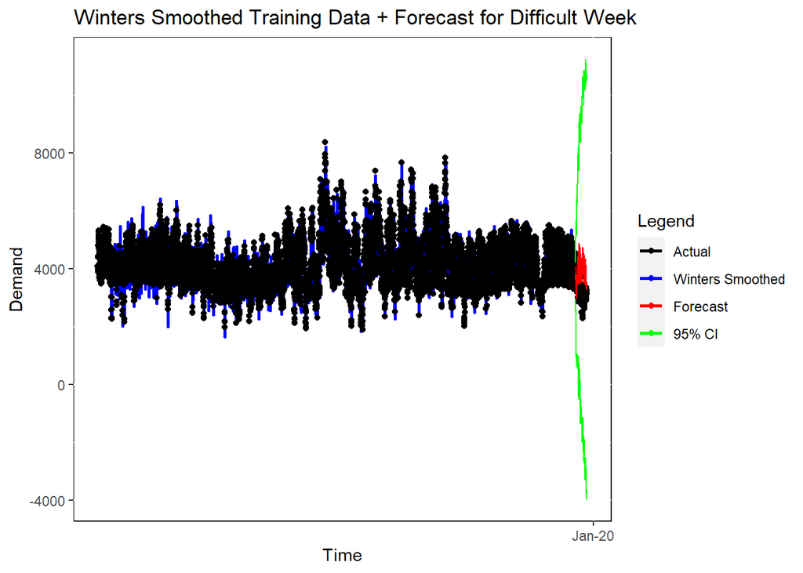

Figure 9: Forecast Plot Created From Scratch for Difficult Week

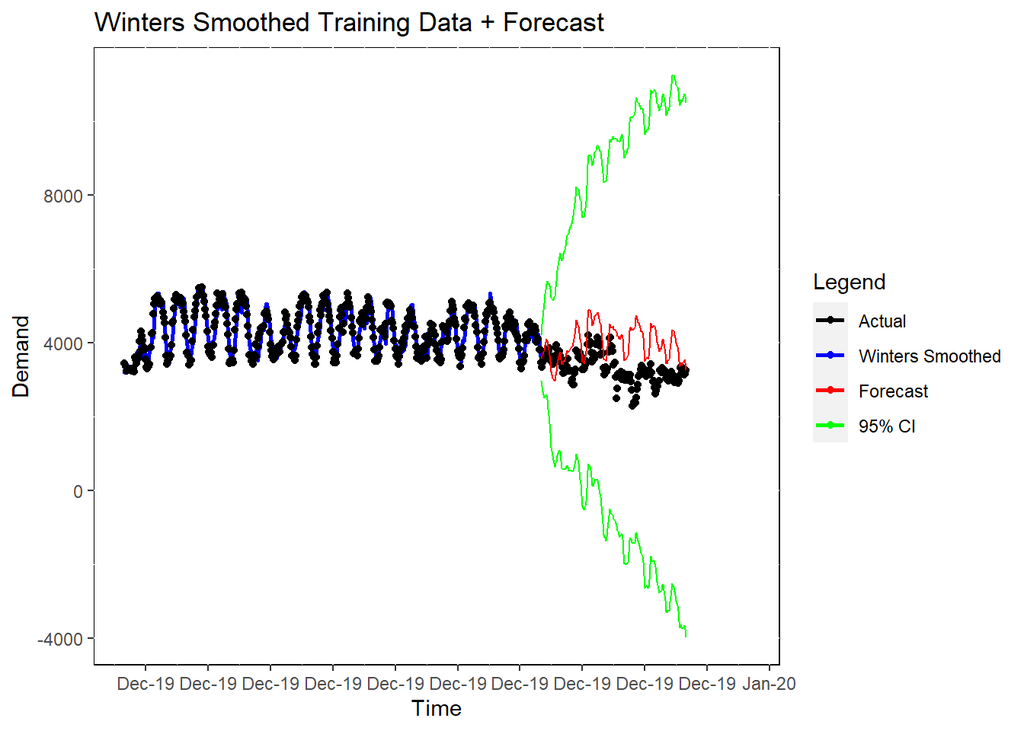

Figure 10: Forecast Plot for last month

Next, the forecast plots with their confidence intervals based on selected model are shown for the easy week.

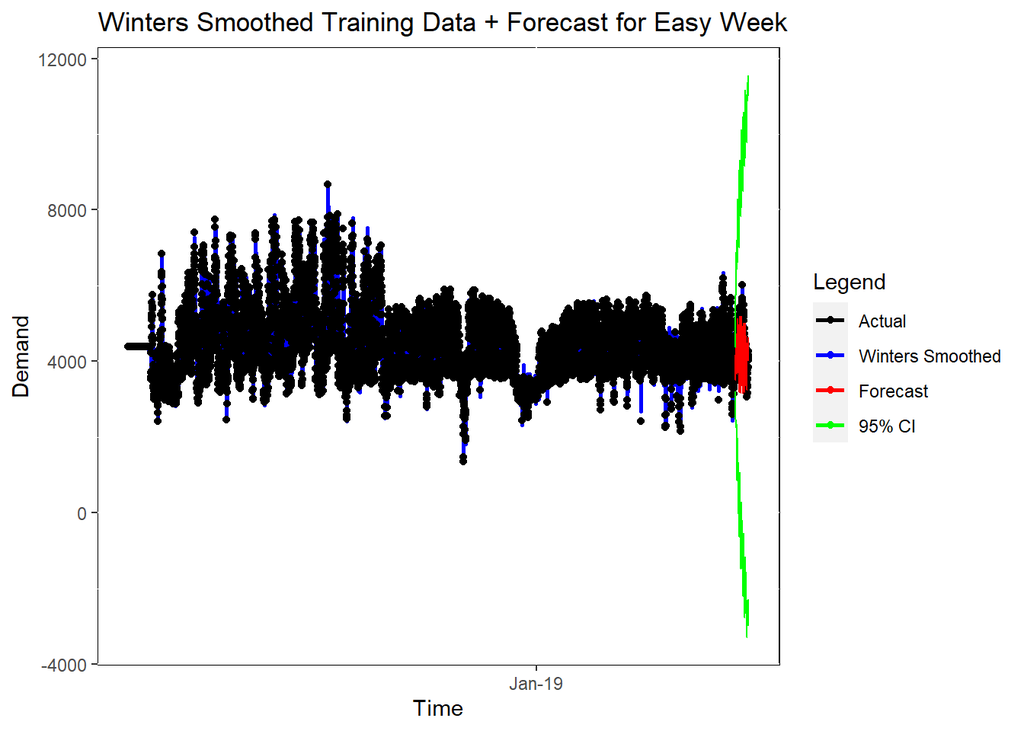

Figure 11: Forecast Plot Created From Scratch for Easy Week

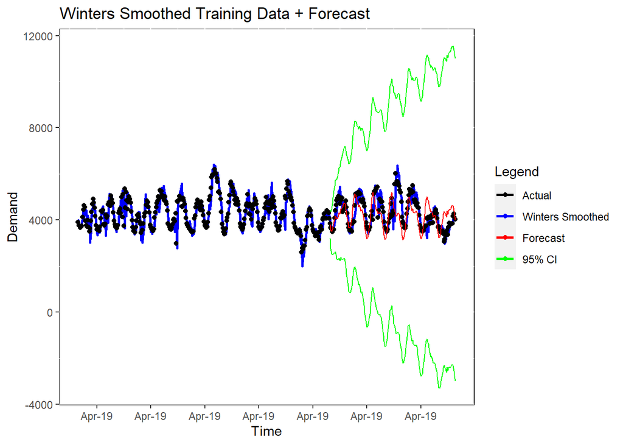

Figure 12: Forecast Plot for last month

For more investigation about the best model, the residuals for both the difficult and easy week has been calculated. The normal probability plot, histogram of errors, errors by time, and errors vs fitted value have been drawn.

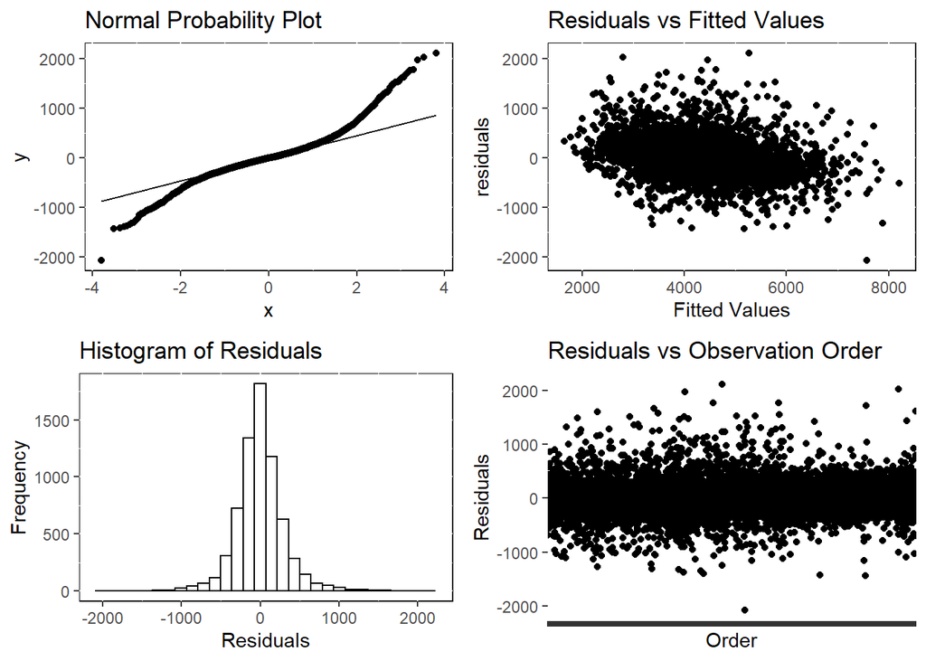

Figure 13: Fancy Residuals plot for Difficult Week

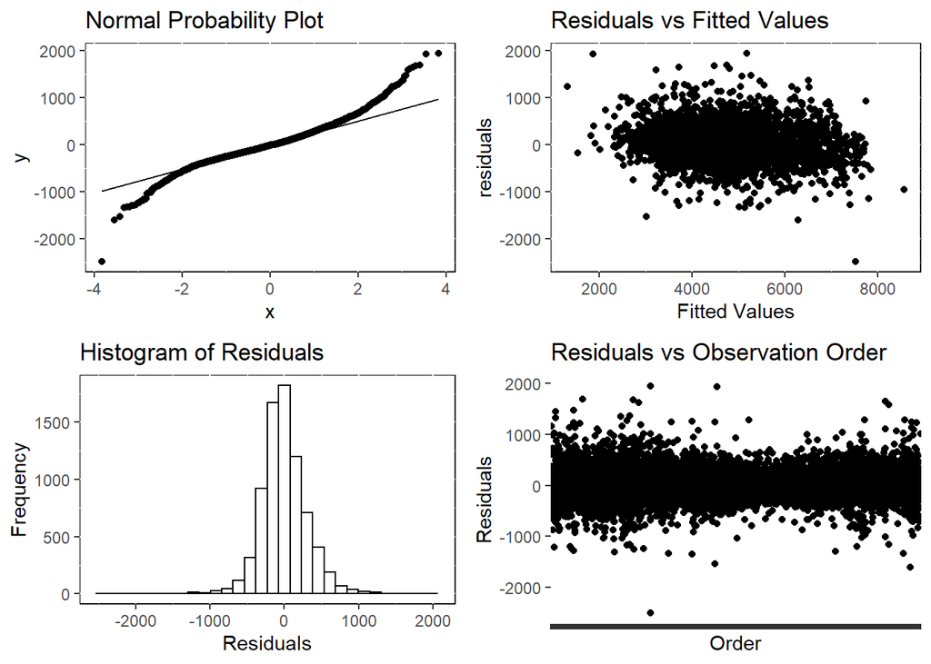

Figure 14: Fancy Residuals plot for Easy Week

For the difficult week, the plots are residuals also are provided. These plots show more variance and change in residuals over time and the normal probability of these residuals also has more differences according to the specified line. All of these differences between the difficult week data set and easy week data set is not that much, so overall our selected model acts good on both training data sets.